# A2

Cristy Medina Armijo

2024-10-08

# Ejercicios del libro de Faraway

(Hall/CRC, n.d.)

Para más información ir a [dataspelunking GitHub](https://github.com/NCSU-STATS/applied-regression-with-R/blob/master/all_hws.pdf).

## Ejercicio 1

El conjunto de datos Teengamb se refiere a un estudio sobre el juego entre adolescentes en Gran Bretaña. Ajuste un modelo de regresión con el gasto en juegos de azar como respuesta y el sexo, el estatus, los ingresos y la puntuación verbal como predictores. Presente un resultado resumido y luego responda/realice lo siguiente.

```r
library(faraway)
data("teengamb")
#teengamb$sex <- factor(teengamb$sex)
#levels(teengamb$sex) <- c("male", "female")
```

```r
fit <- lm(gamble ~ sex+status+income+verbal, data=teengamb)
summary(fit)
```

```
##
## Call:
## lm(formula = gamble ~ sex + status + income + verbal, data = teengamb)
##
## Residuals:
##     Min      1Q  Median      3Q     Max
## -51.082 -11.320  -1.451   9.452  94.252
##
## Coefficients:
##              Estimate Std. Error t value Pr(>|t|)
## (Intercept)  22.55565   17.19680   1.312   0.1968
## sex         -22.11833    8.21111  -2.694   0.0101 *
## status        0.05223    0.28111   0.186   0.8535
## income        4.96198    1.02539   4.839 1.79e-05 ***
## verbal       -2.95949    2.17215  -1.362   0.1803
## ---
## Signif. codes:  0 '***' 0.001 '**' 0.01 '*' 0.05 '.' 0.1 ' ' 1
##
## Residual standard error: 22.69 on 42 degrees of freedom
## Multiple R-squared:  0.5267, Adjusted R-squared:  0.4816
## F-statistic: 11.69 on 4 and 42 DF,  p-value: 1.815e-06
```

**(a) ¿Qué porcentaje de variación en la respuesta se explica por estos predictores?**

```r
var.explained.proportion <-  summary(fit)$r.squared
var.unexplaned.proportion <- 1- summary(fit)$r.squared

#library(pander)
pander(data.frame(var.explained.proportion= var.explained.proportion), caption="Proportion of Variance Explained")
```

Proportion of Variance Explained **(b) ¿Qué observación tiene el residuo (positivo) más grande? Dé el número del caso.**

| var.explained.proportion |
| --- |
| 0.5267 |

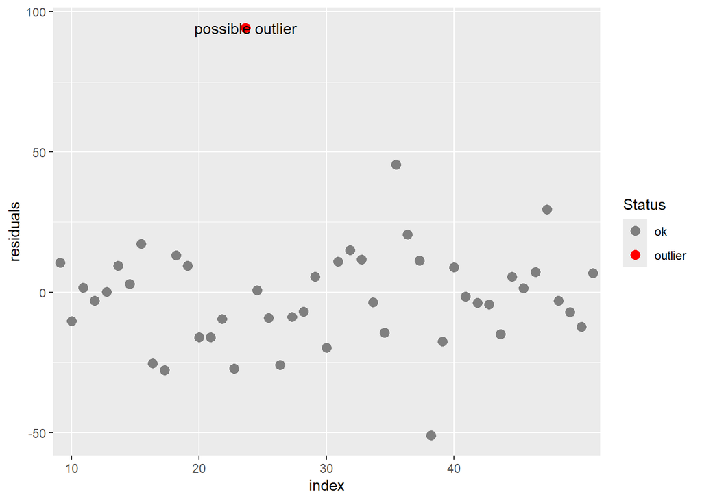

```r
index.largest.pos.residual <- which.max(fit$residuals)

index.largest.abs.residual <- which.max(abs(fit$residuals))

df<- data.frame(residuals = fit$residuals)
df$index <- row.names(df)


df$highlight <- ifelse(df$residuals == max(abs(fit$residuals)), "outlier", "ok")
highlight.colours <- c("outlier" = "red", "ok" = "grey50")

highlight.residual <- max(abs(fit$residuals))
textdf <- df[df$residuals == highlight.residual, ]

ggplot(df,aes(x= index, y=residuals) ) +geom_point(size = 3, aes(colour = highlight))  + scale_x_discrete(breaks=c("10","20","30","40","50")) +
  scale_color_manual("Status", values = highlight.colours) +
    geom_text(data = textdf, aes(x = index, y = residuals), label = "possible outlier")
```

El residuo más grande ocurre en el índice 24 del marco de datos. Estos son los datos del caso asociado.

```r
pander(teengamb[24,], caption = "Potential outlier.")
```

Potential outlier. **(c) Calcule la media y la mediana de los residuos.**

|  | sex | status | income | verbal | gamble |
| --- | --- | --- | --- | --- | --- |
| **24** | 0 | 27 | 10 | 4 | 156 |

```r
residuals.mean <- mean(fit$residuals)

residuals.median <- median(fit$residuals)

pander(data.frame(residuals.mean=residuals.mean,residuals.median=residuals.median), caption = "mean and median of the residuals")
```

mean and median of the residuals

| residuals.mean | residuals.median |
| --- | --- |
| -1.557e-16 | -1.451 |

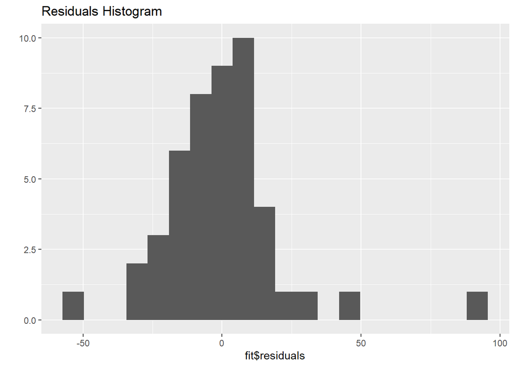

```r
qplot(fit$residuals, geom="histogram", bins = 20 , main = "Residuals Histogram" )
```

```r
sd(fit$residuals)
```

```
## [1] 21.68137
```

**¡El residuo medio es un número muy pequeño! Tendríamos que pensar en las implicaciones de esto; posiblemente sea un artefacto de datos que se generó.**

**Los diagnósticos de regresión se representan a continuación.**

```r
library(ggfortify)
```

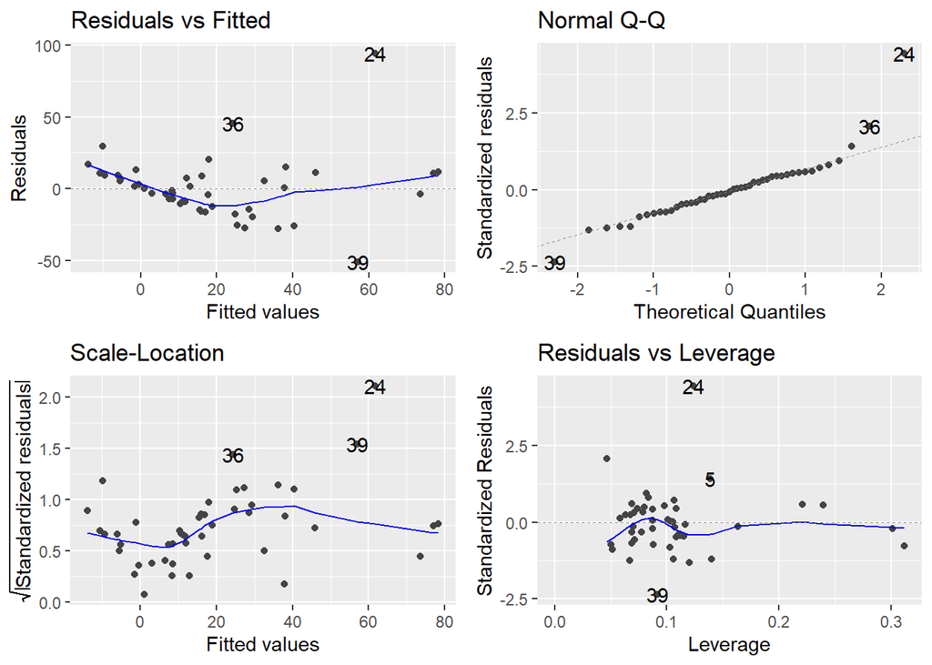

```r
autoplot(fit)
```

**(d) Calcule la correlación de los residuos con los valores ajustados.**

```r
corr.residuals.vs.fitted <- cor(fit$residuals, fit$fitted.values)
pander(data.frame (corr.residuals.vs.fitted=corr.residuals.vs.fitted))
```

| corr.residuals.vs.fitted |
| --- |
| -6.216e-17 |

**(e) Calcule la correlación de los residuos con el ingreso.**

```r
corr.residuals.income <- cor(fit$residuals,teengamb$income)
pander(data.frame (corr.residuals.income=corr.residuals.income))
```

| corr.residuals.income |
| --- |
| 3.247e-17 |

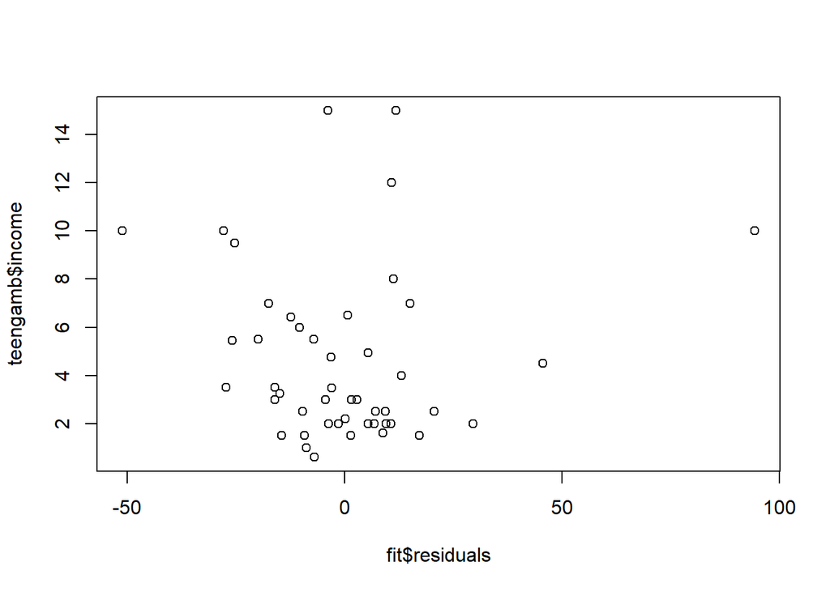

```r
plot(fit$residuals,teengamb$income)
```

**(f) Para todos los demás predictores mantenidos constantes, ¿cuál sería la diferencia en el gasto previsto en juegos de azar para un hombre en comparación con una mujer?**

```r
teengamb$sex <- as.numeric(teengamb$sex)
```

```r
gender.coefficient <- fit$coefficients['sex']

pander(data.frame(gender.coefficient=gender.coefficient))
```

|  | gender.coefficient |
| --- | --- |
| **sex** | -22.12 |

```r
# Extraer coeficientes
coefficients <- coef(fit)

# Encuentra el coeficiente para 'sexo'
coefficient_sex <- coefficients['sex']

# Imprima la diferencia en el gasto previsto para hombres en comparación con mujeres
cat("Difference in predicted expenditure for male compared to female:", coefficient_sex, "\n")
```

```
## Difference in predicted expenditure for male compared to female: -22.11833
```

```r
data.sample<- sample(nrow(teengamb),1)
data.element <- teengamb[data.sample,]
data.element$gamble <-NULL

data.element <- as.matrix(cbind(intercept=1,data.element))
beta.hat <- as.matrix( fit$coefficients)

pander(data.frame(data.element), caption ="Data sample")
```

Data sample

|  | intercept | sex | status | income | verbal |
| --- | --- | --- | --- | --- | --- |
| **47** | 1 | 0 | 71 | 2.5 | 9 |

```r
response.orig <- (data.element) %*% beta.hat

#change the gender of our data element
data.element[1,2] <- ifelse(data.element[1,2]==1, 0, 1)


pander(data.frame(data.element), caption ="Data sample with gender modified")
```

Data sample with gender modified

|  | intercept | sex | status | income | verbal |
| --- | --- | --- | --- | --- | --- |
| **47** | 1 | 1 | 71 | 2.5 | 9 |

```r
response.gendermod <- (data.element) %*% beta.hat

pander(data.frame(response.difference = (response.orig- response.gendermod)))
```

|  | response.difference |
| --- | --- |
| **47** | 22.12 |

## 2. Ejercicio 2

El conjunto de datos sobre salarios se extrae como muestra de la Encuesta de Población Actual de 1988. Ajuste un modelo con salarios semanales como respuesta y años de educación y experiencia como predictores. Reporte y dé una interpretación simple del coeficiente de regresión para años de educación. No se ajusta al mismo modelo pero con salarios semanales registrados. Dé una interpretación al coeficiente de regresión para años de educación. ¿Qué interpretación es más natural?

```r
data(uswages, package="faraway") # import data
lmod2 <- lm(wage ~ educ + exper, data = uswages) # wage as the response (y) and years of education and experience as predictors (x)
summary(lmod2)
```

```
##
## Call:
## lm(formula = wage ~ educ + exper, data = uswages)
##
## Residuals:
##     Min      1Q  Median      3Q     Max
## -1018.2  -237.9   -50.9   149.9  7228.6
##
## Coefficients:
##              Estimate Std. Error t value Pr(>|t|)
## (Intercept) -242.7994    50.6816  -4.791 1.78e-06 ***
## educ          51.1753     3.3419  15.313  < 2e-16 ***
## exper          9.7748     0.7506  13.023  < 2e-16 ***
## ---
## Signif. codes:  0 '***' 0.001 '**' 0.01 '*' 0.05 '.' 0.1 ' ' 1
##
## Residual standard error: 427.9 on 1997 degrees of freedom
## Multiple R-squared:  0.1351, Adjusted R-squared:  0.1343
## F-statistic:   156 on 2 and 1997 DF,  p-value: < 2.2e-16
```

**Como podemos ver arriba, los coeficientes son: (Intercepción) -242.7994, educ 51.1753, exper 9.7748. Entonces, la interpretación es que por cada unidad de aumento en años de educación, el salario aumenta en 51,1753, cuando la experiencia se mantiene fija.**

```r
lmod2logged <- lm(log(wage) ~ educ + exper, data = uswages) # the second model, with logged wages
summary(lmod2logged)
```

```
##
## Call:
## lm(formula = log(wage) ~ educ + exper, data = uswages)
##
## Residuals:
##     Min      1Q  Median      3Q     Max
## -2.7533 -0.3495  0.1068  0.4381  3.5699
##
## Coefficients:
##             Estimate Std. Error t value Pr(>|t|)
## (Intercept) 4.650319   0.078354   59.35   <2e-16 ***
## educ        0.090506   0.005167   17.52   <2e-16 ***
## exper       0.018079   0.001160   15.58   <2e-16 ***
## ---
## Signif. codes:  0 '***' 0.001 '**' 0.01 '*' 0.05 '.' 0.1 ' ' 1
##
## Residual standard error: 0.6615 on 1997 degrees of freedom
## Multiple R-squared:  0.1749, Adjusted R-squared:  0.174
## F-statistic: 211.6 on 2 and 1997 DF,  p-value: < 2.2e-16
```

Como podemos ver arriba, los coeficientes del segundo modelo son: (Intercepción) 4.650319, educ 0.090506, exper 0.018079. La interpretación es que, con la experiencia fijada con un aumento de 1 año en la educación, el salario se convierte en e0,090506 = 1,094728, lo que significa que los salarios aumentan en un 9,4728%.

Para el primer modelo con valores extremos de las covariables existe la posibilidad de obtener un salario negativo, lo que suena realmente ridículo, y el problema se evita en el segundo modelo, ya que la exponenciación es una función no negativa. Entonces podemos decir el segundo modelo ( interpretación) es más natural.

## Ejercicio 3

En esta pregunta, investigamos los méritos relativos de los métodos para calcular los coeficientes. Genere algunos datos artificiales mediante:

> x <- 1:20 y <- x+rnorm(20)

Ajuste un polinomio en x para predecir y. Calcule βˆ de dos maneras: mediante lm() y usando el cálculo directo. culación descrita en el capítulo. ¿A qué grado de polinomio funciona el método de cálculo directo? ¿fallar? (Tenga en cuenta la necesidad de la función I() para ajustar el polinomio, es decir, lm(y ~ x + I(x^2))

```r
x <- 1:20
y <- x + rnorm(20)
```

Ajuste de modelos polinomiales y cálculo de coeficientes:

```r
# Using lm()
fit_lm <- lm(y ~ x + I(x^2) + I(x^3) + I(x^4))
coef_lm <- coef(fit_lm)

# Usando cálculo directo
X <- cbind(1, x, x^2, x^3, x^4)
beta_direct <- solve(t(X) %*% X) %*% t(X) %*% y
```

```r
print(cbind(coef_lm, beta_direct))
```

```
##                   coef_lm
## (Intercept)  2.917123e-03  2.917124e-03
## x            1.239655e+00  1.239655e+00
## I(x^2)      -4.345815e-02 -4.345815e-02
## I(x^3)       1.826713e-03  1.826713e-03
## I(x^4)      -8.536831e-06 -8.536831e-06
```

## Ejercicio 4

El conjunto de datos próstata proviene de un estudio realizado en 97 hombres con cáncer de próstata que debían recibir un prostatectomía radical. Ajuste un modelo con lpsa como respuesta y lcavol como predictor. Registro el error estándar residual y el R2. Ahora agregue lweight, svi, lbph, age, lcp, pgg45 y gleason. al modelo uno a la vez. Para cada modelo registre el error estándar residual y el R2. Trama las tendencias de estas dos estadísticas.

Load data and fit the models

```r
rm(list = ls())
#Esta es una biblioteca del "tidyverse"; la usamos aquí para mostrar los modelos de forma ordenada.
library(broom)

data(prostate, package="faraway")

#Haz un marco de datos para contener los resultados.

model.stats <- data.frame(num.predictors=integer() , r.squared=numeric(), residual.se=numeric(),model.string=character())

lm.fit <- lm(lpsa ~ lcavol, data=prostate)

#Dispaly ambos resúmenes del primer modelo
summary(lm.fit)
```

```
##
## Call:
## lm(formula = lpsa ~ lcavol, data = prostate)
##
## Residuals:
##      Min       1Q   Median       3Q      Max
## -1.67625 -0.41648  0.09859  0.50709  1.89673
##
## Coefficients:
##             Estimate Std. Error t value Pr(>|t|)
## (Intercept)  1.50730    0.12194   12.36   <2e-16 ***
## lcavol       0.71932    0.06819   10.55   <2e-16 ***
## ---
## Signif. codes:  0 '***' 0.001 '**' 0.01 '*' 0.05 '.' 0.1 ' ' 1
##
## Residual standard error: 0.7875 on 95 degrees of freedom
## Multiple R-squared:  0.5394, Adjusted R-squared:  0.5346
## F-statistic: 111.3 on 1 and 95 DF,  p-value: < 2.2e-16
```

```r
tidy(lm.fit)
```

```
## # A tibble: 2 × 5
##   term        estimate std.error statistic  p.value
##   <chr>          <dbl>     <dbl>     <dbl>    <dbl>
## 1 (Intercept)    1.51     0.122       12.4 1.72e-21
## 2 lcavol         0.719    0.0682      10.5 1.12e-17
```

```r
model.summary <- summary(lm.fit)

r.squared <-  model.summary$r.squared
residual.se <-model.summary$sigma
model.string <- "lpsa ~ lcavol"

model.stats <- rbind(list(num.predictors = 1,r.squared=r.squared,residual.se=residual.se,model.string=model.string),model.stats)

#Esto es molesto el paso anterior para agregar el elemento al marco de datos.
#convierte model.string en un factor aunque hayamos especificado que es un carácter cuando creamos el marco de datos.
model.stats$model.string <- as.character(model.stats$model.string)
```

Solo imprimiremos los modelos para predictores $n=2$ y $n=8$.

Fit lpsa ~ lcavol +lweight

```r
lm.fit <- lm(lpsa ~ lcavol +lweight , data=prostate)

tidy(lm.fit)
```

```
## # A tibble: 3 × 5
##   term        estimate std.error statistic  p.value
##   <chr>          <dbl>     <dbl>     <dbl>    <dbl>
## 1 (Intercept)   -0.303    0.569     -0.532 5.96e- 1
## 2 lcavol         0.678    0.0663    10.2   6.12e-17
## 3 lweight        0.511    0.157      3.25  1.61e- 3
```

```r
model.summary <- summary(lm.fit)

r.squared <-  model.summary$r.squared
residual.se <-model.summary$sigma
model.string <- "lpsa ~ lcavol +lweight"

model.stats <- rbind(list(num.predictors = 2,r.squared=r.squared,residual.se=residual.se,model.string=model.string),model.stats)
model.stats$model.string <- as.character(model.stats$model.string)
```

```r
lm.fit <- lm(lpsa ~ lcavol +lweight + svi , data=prostate)

#tidy(lm.fit)

model.summary <- summary(lm.fit)

r.squared <-  model.summary$r.squared
residual.se <-model.summary$sigma
model.string <- "lpsa ~ lcavol +lweight + svi"

model.stats <- rbind(list(num.predictors = 3,r.squared=r.squared,residual.se=residual.se,model.string=model.string),model.stats)
model.stats$model.string <- as.character(model.stats$model.string)
```

```r
lm.fit <- lm(lpsa ~ lcavol +lweight + svi + lbph , data=prostate)

#tidy(lm.fit)

model.summary <- summary(lm.fit)

r.squared <-  model.summary$r.squared
residual.se <-model.summary$sigma
model.string <- "lpsa ~ lcavol +lweight + svi + lbph"

model.stats <- rbind(list(num.predictors = 4,r.squared=r.squared,residual.se=residual.se,model.string=model.string),model.stats)
model.stats$model.string <- as.character(model.stats$model.string)
```

```r
lm.fit <- lm(lpsa ~ lcavol +lweight + svi + lbph + age , data=prostate)

#tidy(lm.fit)

model.summary <- summary(lm.fit)

r.squared <-  model.summary$r.squared
residual.se <-model.summary$sigma
model.string <- "lpsa ~ lcavol +lweight + svi + lbph + age"

model.stats <- rbind(list(num.predictors = 5,r.squared=r.squared,residual.se=residual.se,model.string=model.string),model.stats)
model.stats$model.string <- as.character(model.stats$model.string)
```

```r
lm.fit <- lm(lpsa ~ lcavol +lweight + svi + lbph + age + lcp , data=prostate)

#tidy(lm.fit)

model.summary <- summary(lm.fit)

r.squared <-  model.summary$r.squared
residual.se <-model.summary$sigma
model.string <- "lpsa ~ lcavol +lweight + svi + lbph + age + lcp"

model.stats <- rbind(list(num.predictors = 6,r.squared=r.squared,residual.se=residual.se,model.string=model.string),model.stats)
model.stats$model.string <- as.character(model.stats$model.string)
```

```r
lm.fit <- lm(lpsa ~ lcavol +lweight + svi + lbph + age + lcp + pgg45, data=prostate)

#tidy(lm.fit)

model.summary <- summary(lm.fit)

r.squared <-  model.summary$r.squared
residual.se <-model.summary$sigma
model.string <- "lpsa ~ lcavol +lweight + svi + lbph + age + lcp + pgg45"

model.stats <- rbind(list(num.predictors = 7,r.squared=r.squared,residual.se=residual.se,model.string=model.string),model.stats)
model.stats$model.string <- as.character(model.stats$model.string)
```

Fit lpsa ~ lcavol +lweight + svi + lbph + age + lcp + pgg45+ gleason

```r
lm.fit <- lm(lpsa ~ lcavol +lweight + svi + lbph + age + lcp + pgg45+ gleason, data=prostate)

tidy(lm.fit)
```

```
## # A tibble: 9 × 5
##   term        estimate std.error statistic       p.value
##   <chr>          <dbl>     <dbl>     <dbl>         <dbl>
## 1 (Intercept)  0.669     1.30        0.516 0.607
## 2 lcavol       0.587     0.0879      6.68  0.00000000211
## 3 lweight      0.454     0.170       2.67  0.00896
## 4 svi          0.766     0.244       3.14  0.00233
## 5 lbph         0.107     0.0584      1.83  0.0704
## 6 age         -0.0196    0.0112     -1.76  0.0823
## 7 lcp         -0.105     0.0910     -1.16  0.250
## 8 pgg45        0.00453   0.00442     1.02  0.309
## 9 gleason      0.0451    0.157       0.287 0.775
```

```r
model.summary <- summary(lm.fit)

r.squared <-  model.summary$r.squared
residual.se <-model.summary$sigma
model.string <- "lpsa ~ lcavol +lweight + svi + lbph + age + lcp + pgg45+ gleason"

model.stats <- rbind(list(num.predictors = 8,r.squared=r.squared,residual.se=residual.se,model.string=model.string),model.stats)
model.stats$model.string <- as.character(model.stats$model.string)
```

Present the model stats

```r
rownames(model.stats) <- NULL
pander(model.stats, caption = "model statistics")
```

model statistics Plot $SE$ versus $R^2$

| num.predictors | r.squared | residual.se | model.string |
| --- | --- | --- | --- |
| 8 | 0.6548 | 0.7084 | lpsa ~ lcavol +lweight + svi + lbph + age + lcp + pgg45+ gleason |
| 7 | 0.6544 | 0.7048 | lpsa ~ lcavol +lweight + svi + lbph + age + lcp + pgg45 |
| 6 | 0.6451 | 0.7102 | lpsa ~ lcavol +lweight + svi + lbph + age + lcp |
| 5 | 0.6441 | 0.7073 | lpsa ~ lcavol +lweight + svi + lbph + age |
| 4 | 0.6366 | 0.7108 | lpsa ~ lcavol +lweight + svi + lbph |
| 3 | 0.6264 | 0.7168 | lpsa ~ lcavol +lweight + svi |
| 2 | 0.5859 | 0.7506 | lpsa ~ lcavol +lweight |
| 1 | 0.5394 | 0.7875 | lpsa ~ lcavol |

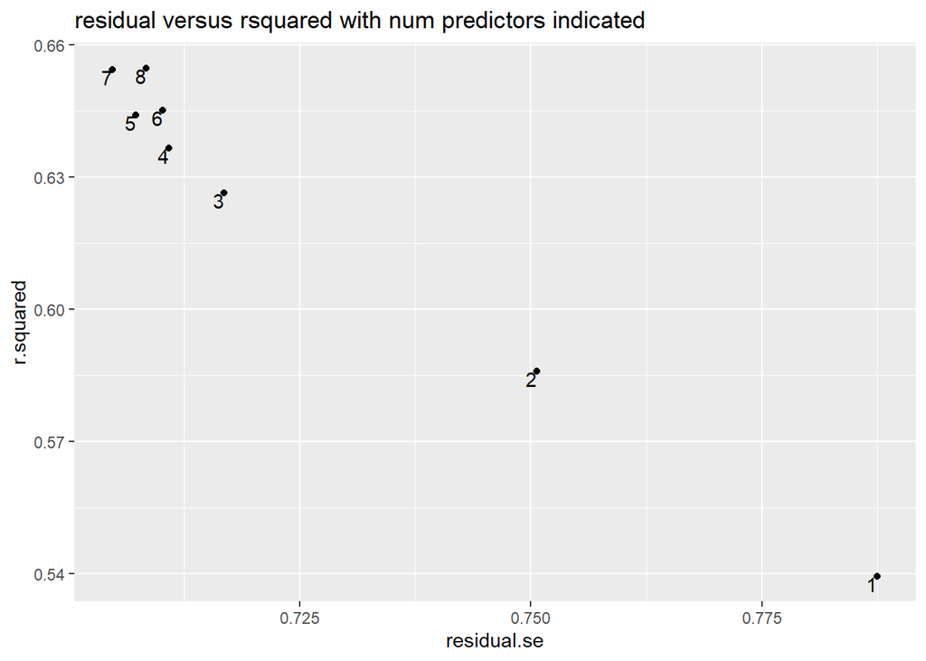

```r
p<-ggplot(model.stats, aes(x=residual.se,y=r.squared)) + geom_point()
p<- p+ geom_text(aes(label=num.predictors, num.predictors="red", hjust=1, vjust=1))
p + ggtitle("residual versus rsquared with num predictors indicated")
```

Vemos que generalmente la proporción de varianza explicada por el modelo aumenta y el error estándar residual disminuye a medida que aumenta la dimensión del modelo. El efecto se vuelve menos pronunciado a medida que llegamos a 6+ predictores. Se podría argumentar que la inclusión de Gleason en el modelo no añade mucho poder explicativo. Esto puede tener sentido empírico ya que la puntuación de Gleason la asigna un patólogo basándose en un portaobjetos de tejido teñido. Podría darse el caso de que esta característica resuma o sea un indicador débil de las variables bioquímicas.

## Ejercicio 5

Utilizando los datos de la próstata, grafique lpsa frente a lcavol. Ajuste las regresiones de lpsa sobre lcavol y lcavol sobre lpsa. Muestre ambas líneas de regresión en el gráfico. ¿En qué punto se cruzan las dos rectas?

```r
data(prostate, package='faraway')
head(prostate)
```

```
##       lcavol lweight age      lbph svi      lcp gleason pgg45     lpsa
## 1 -0.5798185  2.7695  50 -1.386294   0 -1.38629       6     0 -0.43078
## 2 -0.9942523  3.3196  58 -1.386294   0 -1.38629       6     0 -0.16252
## 3 -0.5108256  2.6912  74 -1.386294   0 -1.38629       7    20 -0.16252
## 4 -1.2039728  3.2828  58 -1.386294   0 -1.38629       6     0 -0.16252
## 5  0.7514161  3.4324  62 -1.386294   0 -1.38629       6     0  0.37156
## 6 -1.0498221  3.2288  50 -1.386294   0 -1.38629       6     0  0.76547
```

```r
summary(prostate)
```

```
##      lcavol           lweight           age             lbph
##  Min.   :-1.3471   Min.   :2.375   Min.   :41.00   Min.   :-1.3863
##  1st Qu.: 0.5128   1st Qu.:3.376   1st Qu.:60.00   1st Qu.:-1.3863
##  Median : 1.4469   Median :3.623   Median :65.00   Median : 0.3001
##  Mean   : 1.3500   Mean   :3.653   Mean   :63.87   Mean   : 0.1004
##  3rd Qu.: 2.1270   3rd Qu.:3.878   3rd Qu.:68.00   3rd Qu.: 1.5581
##  Max.   : 3.8210   Max.   :6.108   Max.   :79.00   Max.   : 2.3263
##       svi              lcp             gleason          pgg45
##  Min.   :0.0000   Min.   :-1.3863   Min.   :6.000   Min.   :  0.00
##  1st Qu.:0.0000   1st Qu.:-1.3863   1st Qu.:6.000   1st Qu.:  0.00
##  Median :0.0000   Median :-0.7985   Median :7.000   Median : 15.00
##  Mean   :0.2165   Mean   :-0.1794   Mean   :6.753   Mean   : 24.38
##  3rd Qu.:0.0000   3rd Qu.: 1.1786   3rd Qu.:7.000   3rd Qu.: 40.00
##  Max.   :1.0000   Max.   : 2.9042   Max.   :9.000   Max.   :100.00
##       lpsa
##  Min.   :-0.4308
##  1st Qu.: 1.7317
##  Median : 2.5915
##  Mean   : 2.4784
##  3rd Qu.: 3.0564
##  Max.   : 5.5829
```

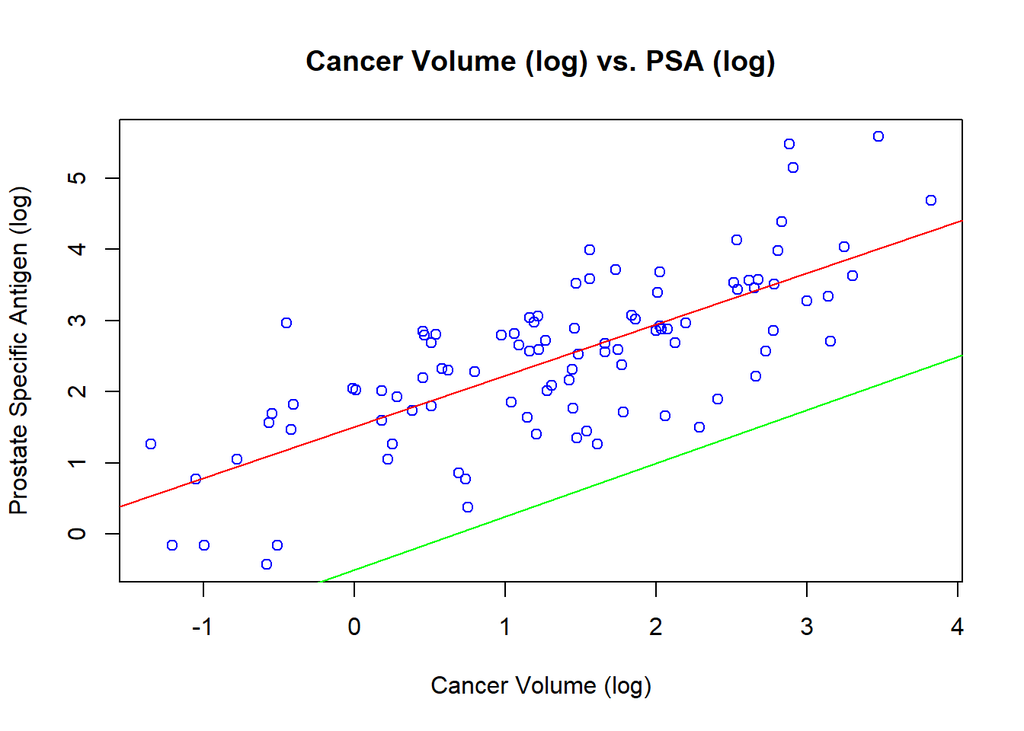

```r
plot(x=prostate$lcavol,y=prostate$lpsa, type='p',col="blue", main="Cancer Volume (log) vs. PSA (log)", xlab="Cancer Volume (log)", ylab="Prostate Specific Antigen (log)")

lmod_1 <- lm(lpsa ~ lcavol, prostate)
abline(lmod_1, col='red')
lmod_2 <- lm(lcavol ~ lpsa, prostate)
abline(lmod_2, col='green')
```

## Ejercicio 6

Se analizaron treinta muestras de queso cheddar para determinar su contenido de ácido acético, sulfuro de hidrógeno y ácido láctico. Cada muestra fue probada y calificada por un panel de jueces y la puntuación de sabor promedio producido. Utilice los datos del queso cheddar para responder lo siguiente:

**(a) Ajuste un modelo de regresión con el sabor como respuesta y los tres contenidos químicos como predictores.** **Informe los valores de los coeficientes de regresión.**

```r
lm.fit <- lm(taste ~ Acetic + H2S + Lactic, data=cheddar)
```

[output not shown]

[output not shown]

Vemos que $H2S$ y $Lactic$ son significativos para el nivel $5\%$.

Para deshacer la transformación del registro necesitamos la base; esto no se especifica en la sección de ayuda del conjunto de datos. Dado que estamos tratando con datos de concentración química, y basándonos en la parte e), asumiremos que $Acético$ y $H2S$ se miden en una escala $Log_{e}$.

```r
lm.fit.exp <- lm(taste ~ I(exp(1)^Acetic) + I(exp(1)^H2S) + Lactic, data=cheddar)
```

[output not shown]

taste ~ I(exp(1)^Acetic) + I(exp(1)^H2S) + Lactic

[output not shown]

No podemos utilizar una prueba F para comparar estos modelos ya que no están anidados. El ajuste del modelo en la escala $ln$ se ajusta mejor a los datos según los criterios $R^2$.

Para el ajuste del modelo en la parte a), vimos que $\beta_{H2S} = 3,9118$, esto significa que mantener constantes todas las demás variables y aumentar $H2S$ en $0,01$ aumenta el sabor en $0,039118$. Podemos verificar que este es el caso numéricamente en un elemento de datos de ejemplo del conjunto de entrenamiento.

```r
data.sample<- sample(nrow(cheddar),1)
data.element <- cheddar[data.sample,]
data.element$taste <-NULL
data.element <- as.matrix(cbind(intercept=1,data.element))
beta.hat <- as.matrix( lm.fit$coefficients)
pander(data.frame(data.element), caption ="Data sample")
```

Data sample

|  | intercept | Acetic | H2S | Lactic |
| --- | --- | --- | --- | --- |
| **11** | 1 | 5.74 | 6.142 | 1.68 |

```r
response.orig <- (data.element) %*% beta.hat
#change the of our data element H2S by +0.01
data.element[1,3] <- data.element[1,3] + 0.01
pander(data.frame(data.element), caption ="Data sample data element H2S increased by +0.01")
```

Data sample data element H2S increased by +0.01

|  | intercept | Acetic | H2S | Lactic |
| --- | --- | --- | --- | --- |
| **11** | 1 | 5.74 | 6.152 | 1.68 |

```r
response.mod <- (data.element) %*% beta.hat
pander(data.frame(response.difference = (response.mod - response.orig)))
```

|  | response.difference |
| --- | --- |
| **11** | 0.03912 |

## Ejercicio 7

Se realizó un experimento para determinar el efecto de cuatro factores sobre la resistividad de un semi- oblea conductora. Los datos se encuentran en una oblea donde cada uno de los cuatro factores está codificado como − o + dependiendo de si se utilizó la configuración baja o alta para ese factor. Ajustar el modelo lineal resistir ~ x1 + x2 + x3 + x4.

```r
rm(list = ls())
data(wafer, package="faraway")

print("Inspect Data")
```

```
## [1] "Inspect Data"
```

```r
head(wafer)
```

```
##   x1 x2 x3 x4 resist
## 1  -  -  -  -  193.4
## 2  +  -  -  -  247.6
## 3  -  +  -  -  168.2
## 4  +  +  -  -  205.0
## 5  -  -  +  -  303.4
## 6  +  -  +  -  339.9
```

```r
print("check the class of the columns")
```

```
## [1] "check the class of the columns"
```

```r
lapply(wafer, class)
```

```
## $x1
## [1] "factor"
##
## $x2
## [1] "factor"
##
## $x3
## [1] "factor"
##
## $x4
## [1] "factor"
##
## $resist
## [1] "numeric"
```

```r
print("Fi the model")
```

```
## [1] "Fi the model"
```

```r
lm.fit <- lm( resist ~ x1 + x2 + x3 + x4 , data=wafer)
```

**a) Extraiga la matriz X utilizando la función model.matrix. Examine esto para determinar cómo** **Los niveles bajos y altos han sido codificados en el modelo.**

```r
model.matrix(lm.fit)
```

```
##    (Intercept) x1+ x2+ x3+ x4+
## 1            1   0   0   0   0
## 2            1   1   0   0   0
## 3            1   0   1   0   0
## 4            1   1   1   0   0
## 5            1   0   0   1   0
## 6            1   1   0   1   0
## 7            1   0   1   1   0
## 8            1   1   1   1   0
## 9            1   0   0   0   1
## 10           1   1   0   0   1
## 11           1   0   1   0   1
## 12           1   1   1   0   1
## 13           1   0   0   1   1
## 14           1   1   0   1   1
## 15           1   0   1   1   1
## 16           1   1   1   1   1
## attr(,"assign")
## [1] 0 1 2 3 4
## attr(,"contrasts")
## attr(,"contrasts")$x1
## [1] "contr.treatment"
##
## attr(,"contrasts")$x2
## [1] "contr.treatment"
##
## attr(,"contrasts")$x3
## [1] "contr.treatment"
##
## attr(,"contrasts")$x4
## [1] "contr.treatment"
```

Ahora veamos la matriz de datos para ver cómo se codifican los factores

```r
pander(wafer)
```

| x1 | x2 | x3 | x4 | resist |
| --- | --- | --- | --- | --- |
| - | - | - | - | 193.4 |
| + | - | - | - | 247.6 |
| - | + | - | - | 168.2 |
| + | + | - | - | 205 |
| - | - | + | - | 303.4 |
| + | - | + | - | 339.9 |
| - | + | + | - | 226.3 |
| + | + | + | - | 208.3 |
| - | - | - | + | 220 |
| + | - | - | + | 256.4 |
| - | + | - | + | 165.7 |
| + | + | - | + | 203.5 |
| - | - | + | + | 285 |
| + | - | + | + | 268 |
| - | + | + | + | 169.1 |
| + | + | + | + | 208.5 |

Comparando la matriz del modelo con el marco de datos original, vemos que el nivel bajo $- \longrightarrow 0$ y el nivel alto $+ \longrightarrow 1$

**(b) Calcule la correlación en la matriz X. ¿Por qué faltan algunos valores en la matriz?**

```r
pander(data.frame(cor(model.matrix(lm.fit))), caption = "Correlation of X")
```

Correlation of X La correlación en la matriz $X$ son los valores por pares de las correlaciones de las columnas. La correlación es la covarianza dividida por la raíz cuadrada del producto de las dos varianzas.

|  | X.Intercept. | x1. | x2. | x3. | x4. |
| --- | --- | --- | --- | --- | --- |
| **(Intercept)** | 1 | NA | NA | NA | NA |
| **x1+** | NA | 1 | 0 | 0 | 0 |
| **x2+** | NA | 0 | 1 | 0 | 0 |
| **x3+** | NA | 0 | 0 | 1 | 0 |
| **x4+** | NA | 0 | 0 | 0 | 1 |

*Si $X$ y $Y$ son variables aleatorias distribuidas conjuntamente y las varianzas y covarianzas de $X$ e $Y$ existen y las varianzas son distintas de cero, entonces la correlación de $X$ y $Y$, denotada por, es $\rho= Cov(X, Y ) / \sqrt{ Var(X)Var(Y)}$*

En este caso estamos tratando con muestras y calculando las correlaciones muestrales.

Hay NaN debido a la intercepción. La varianza de este vector es 0 y cuando R intenta dividir por 0 en el cálculo de $\rho_{i,j}$ el resultado es un NaN. Tenga en cuenta que R establece la diagonal de la correlación en uno (no calcula el valor), por eso vemos $\rho_{1,1}=1$.

Notamos que los términos $i= \neq j$ para $i,j>1$ eran cero; esto causa preocupación y escribimos un código de prueba para validar las entradas. Se verificó que los valores eran correctos.

```r
MM<- model.matrix(lm.fit)
#
# colMeans <- colSums(MM)/nrow(MM)
#
# corr_ij <- function(i,j,MM){return( t(MM[,i] - mean(MM[,i])) %*% (MM[,j]-mean(MM[,j])) /sqrt(var(MM[,i]*var(MM[,j]))) ) }
#
# corr_ij(2,3,MM)
# corr_ij(3,4,MM)
# corr_ij(2,4,MM)
```

**(d) ¿Reajustar el modelo sin x4 y examinar los coeficientes de regresión y los errores estándar? Qué** **¿Se mantuvo igual que el ajuste original y qué cambió?**

Reduced Model

```r
lm.fit.reduced <- lm( resist ~ x1 + x2 + x3 , data=wafer)

summary(lm.fit.reduced)
```

```
##
## Call:
## lm(formula = resist ~ x1 + x2 + x3, data = wafer)
##
## Residuals:
##     Min      1Q  Median      3Q     Max
## -36.137 -20.550   3.575  18.463  41.012
##
## Coefficients:
##             Estimate Std. Error t value Pr(>|t|)
## (Intercept)   229.54      13.32  17.231 7.88e-10 ***
## x1+            25.76      13.32   1.934 0.077047 .
## x2+           -69.89      13.32  -5.246 0.000206 ***
## x3+            43.59      13.32   3.272 0.006677 **
## ---
## Signif. codes:  0 '***' 0.001 '**' 0.01 '*' 0.05 '.' 0.1 ' ' 1
##
## Residual standard error: 26.64 on 12 degrees of freedom
## Multiple R-squared:  0.7777, Adjusted R-squared:  0.7221
## F-statistic: 13.99 on 3 and 12 DF,  p-value: 0.0003187
```

**(e) Explique cómo se relaciona el cambio en los coeficientes de regresión con la matriz de correlación de X.**

Cuando la matriz del modelo es ortogonal, la matriz de covarianza de la distribución muestral de los parámetros de regresión será diagonal, cuando el error sea iid $N(0,\sigma)$.

$$\hat{\beta} \sim N(\beta, \sigma
(\textbf{X}^\intercal \textbf{X} )^{-1} )$$

podemos verificar
$$(\textbf{X}^\intercal
\textbf{X} )^{-1} (\textbf{X}^\intercal \textbf{X} ) = I$$

para nuestra matriz modelo

```r
solve(t(MM) %*% MM) %*% t(MM)%*% MM
```

```
##             (Intercept) x1+ x2+ x3+ x4+
## (Intercept)           1   0   0   0   0
## x1+                   0   1   0   0   0
## x2+                   0   0   1   0   0
## x3+                   0   0   0   1   0
## x4+                   0   0   0   0   1
```

# Ejercicios del libro de Carmona

(Pontaque 2005)

## Ejercicio 2.1

Lineal

No lineal

No lineal

Un modelo lineal es aquel en el que la variable respuesta (en este caso, Y) es una combinación lineal de los parámetros (β) y las variables predictoras (X), más un término de error (ε).

En el modelo a), aunque hay un término cuadrático en x, el modelo sigue siendo lineal en los parámetros porque el término cuadrático se ha expresado como una combinación lineal de los parámetros β0, β1 y β2.

## Ejercicio 2.4

Cuatro objetos cuyos pesos exactos son β1, β2, β3 y β4 han sido pesados en una balanza de platillos de acuerdo con el siguiente esquema:

β1 β2 β3 β4 peso 1 1 1 1 9.2 1 −1 1 1 8.3 1 0 0 1 5.4 1 0 0 −1 −1.6 1 0 1 1 8.7 1 1 −1 1 3.5 Hallar las estimaciones de cada βi y de la varianza del error.

```r
# Datos
y <- c(9.2, 8.3, 5.4, -1.6, 8.7, 3.5)
X <- matrix(c(1,1,1,1,
              1,-1,1,1,
              1,0,0,1,
              1,0,0,-1,
              1,0,1,1,
              1,1,-1,1), nrow=6, byrow=TRUE)

# Estimación de los parámetros
beta_hat <- solve(t(X) %*% X) %*% t(X) %*% y

# Cálculo de los residuos
residuals <- y - X %*% beta_hat

# Varianza del error
sigma_squared <- sum(residuals^2) / (nrow(X) - ncol(X))

# Imprimir resultados
print("Estimaciones de los pesos:")
```

```
## [1] "Estimaciones de los pesos:"
```

```r
print(beta_hat)
```

```
##           [,1]
## [1,] 2.0685714
## [2,] 0.5342857
## [3,] 2.9400000
## [4,] 3.6685714
```

```r
print("Varianza del error:")
```

```
## [1] "Varianza del error:"
```

```r
print(sigma_squared)
```

```
## [1] 0.08371429
```

En un modelo lineal, la matriz de diseño es

1 1 1 1 1 1 0 1 0 0 1 1 1 0 0 1 0 1 1 1

Hallar la expresión general de las funciones paramétricas estimables.

```r
X <- matrix(c(1, 1, 1, 1, 1,
              1, 0, 1, 0, 0,
              1, 1, 1, 0, 0,
              1, 0, 1, 1, 1), nrow = 4, byrow = TRUE)
```

```r
library(Matrix)
rankMatrix(X)
```

```
## [1] 3
## attr(,"method")
## [1] "tolNorm2"
## attr(,"useGrad")
## [1] FALSE
## attr(,"tol")
## [1] 1.110223e-15
```

```r
# Generando coeficientes aleatorios para las combinaciones lineales
set.seed(123)
num_combinations <- 10
combinations <- matrix(runif(num_combinations * 3), nrow = num_combinations, ncol = 3)

# Mostrando las combinaciones
for (i in 1:num_combinations) {
  print(paste(combinations[i, 1], "* beta1 +", combinations[i, 2], "* beta2 +", combinations[i, 3], "* beta4"))
}
```

```
## [1] "0.287577520124614 * beta1 + 0.956833345349878 * beta2 + 0.889539316063747 * beta4"
## [1] "0.788305135443807 * beta1 + 0.453334156190977 * beta2 + 0.6928034061566 * beta4"
## [1] "0.4089769218117 * beta1 + 0.677570635452867 * beta2 + 0.640506813768297 * beta4"
## [1] "0.883017404004931 * beta1 + 0.572633401956409 * beta2 + 0.994269776623696 * beta4"
## [1] "0.940467284293845 * beta1 + 0.102924682665616 * beta2 + 0.655705799115822 * beta4"
## [1] "0.0455564993899316 * beta1 + 0.899824970401824 * beta2 + 0.708530468167737 * beta4"
## [1] "0.528105488047004 * beta1 + 0.24608773435466 * beta2 + 0.544066024711356 * beta4"
## [1] "0.892419044394046 * beta1 + 0.0420595335308462 * beta2 + 0.59414202044718 * beta4"
## [1] "0.551435014465824 * beta1 + 0.327920719282702 * beta2 + 0.28915973729454 * beta4"
## [1] "0.456614735303447 * beta1 + 0.954503649147227 * beta2 + 0.147113647311926 * beta4"
```

## References

Hall/CRC, Chapman y, ed. n.d.

Pontaque, F. C. 2005. *Modelos Lineales*. E-UMAB. Publicacions i Edicions de la Universitat de Barcelona. https://books.google.es/books?id=H2e_BAAAQBAJ.